# Chapter 5

Suvi Vainio

2 joulukuuta 2018

# Dimensionality reduction techniques

The data for this week’s exercise is the UN human development index data that was manipulated by the course assistants.

Long names for the variables can be found in: https://raw.githubusercontent.com/TuomoNieminen/Helsinki-Open-Data-Science/master/datasets/human_meta.txt

The data has a couple of linear relationships (for example between life-expectancy and expected years of schooling, or the women to men ratio in secondary education). There is also relationships that look more polynomial than linear in nature, for example maternal mortality ratio seems to have a ‘curvy’ relationship with many of the other variables, e.g. life-expectancy or expected years in schooling.

There exist also large correlations in the data set (>0.5), which indicates that variables might be describing an underlying and unobserved dimension and thus dimensionality reduction makes sense here.

```
## 'data.frame':    154 obs. of  8 variables:
##  $ Edu2.FM  : num  1.007 0.997 0.983 0.989 0.969 ...
##  $ Labo.FM  : num  0.891 0.819 0.825 0.884 0.829 ...
##  $ Edu.Exp  : num  17.5 20.2 15.8 18.7 17.9 16.5 18.6 16.5 15.9 19.2 ...
##  $ Life.Exp : num  81.6 82.4 83 80.2 81.6 80.9 80.9 79.1 82 81.8 ...
##  $ GNI      : num  64992 42261 56431 44025 45435 ...
##  $ Mat.Mor  : int  4 6 6 5 6 7 9 28 11 8 ...
##  $ Ado.Birth: num  7.8 12.1 1.9 5.1 6.2 3.8 8.2 31 14.5 25.3 ...
##  $ Parli.F  : num  39.6 30.5 28.5 38 36.9 36.9 19.9 19.4 28.2 31.4 ...
```

```
##     Edu2.FM          Labo.FM          Edu.Exp         Life.Exp
##  Min.   :0.1717   Min.   :0.1857   Min.   : 5.40   Min.   :49.00
##  1st Qu.:0.7427   1st Qu.:0.5981   1st Qu.:11.30   1st Qu.:66.42
##  Median :0.9402   Median :0.7529   Median :13.50   Median :74.20
##  Mean   :0.8559   Mean   :0.7065   Mean   :13.21   Mean   :71.79
##  3rd Qu.:0.9968   3rd Qu.:0.8531   3rd Qu.:15.20   3rd Qu.:77.28
##  Max.   :1.4967   Max.   :1.0380   Max.   :20.20   Max.   :83.50
##       GNI            Mat.Mor          Ado.Birth         Parli.F
##  Min.   :   680   Min.   :   1.00   Min.   :  0.60   Min.   : 0.00
##  1st Qu.:  4495   1st Qu.:  11.25   1st Qu.: 12.62   1st Qu.:12.40
##  Median : 12081   Median :  49.00   Median : 33.20   Median :19.35
##  Mean   : 17739   Mean   : 144.34   Mean   : 46.83   Mean   :20.97
##  3rd Qu.: 24518   3rd Qu.: 190.00   3rd Qu.: 71.78   3rd Qu.:28.07
##  Max.   :123124   Max.   :1100.00   Max.   :204.80   Max.   :57.50
```

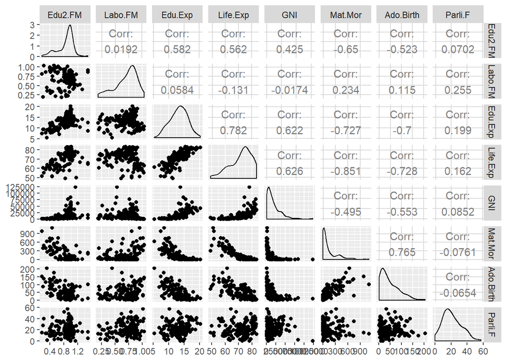

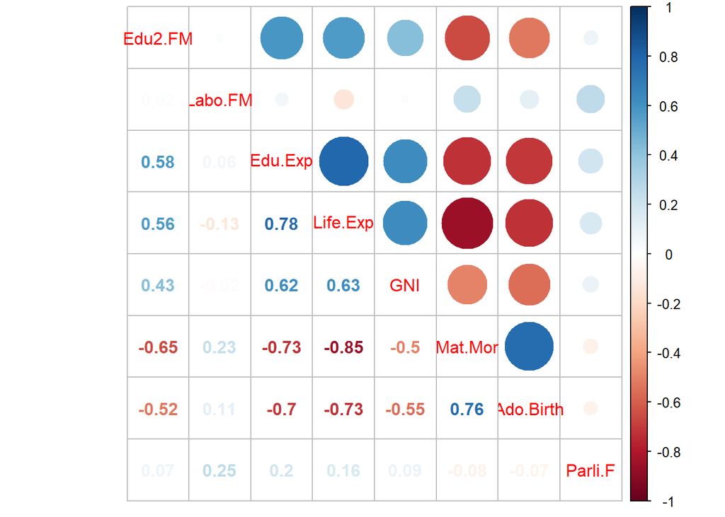

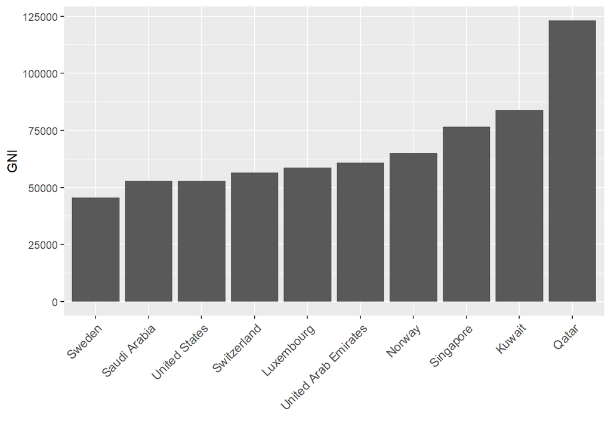

## Principal component analysis

The first principal component analysis is performed on the non-standardized dataset. PCA is sensitive to scales and variances and in the data set the ranges vary a lot.

Indeed the unstandardized principle component analysis manages to differentiate between countries that are materially very well of (like Kuwait, Singapore, Norway and the USA). In this case using just GNI is simpler and this complex analysis does not add a lot of value. First component captures 100 % of the variance.

```
## Standard deviations (1, .., p=8):
## [1] 1.652100e+04 1.747522e+02 2.479978e+01 1.124852e+01 3.699487e+00
## [6] 1.537905e+00 1.924201e-01 1.599784e-01
##
## Rotation (n x k) = (8 x 8):
##                     PC1           PC2           PC3           PC4
## Edu2.FM   -6.259677e-06 -0.0006771787 -6.614863e-05 -0.0002971124
## Labo.FM   -2.088355e-07  0.0003213676  4.296033e-04 -0.0044154107
## Edu.Exp   -1.181029e-04 -0.0068810560  1.170346e-02 -0.0242860527
## Life.Exp  -3.343840e-04 -0.0273215059  7.367941e-03 -0.0516563085
## GNI       -9.999773e-01  0.0067035584 -6.051895e-04  0.0001453210
## Mat.Mor    6.563577e-03  0.9913459128  1.283503e-01 -0.0033435764
## Ado.Birth  1.458569e-03  0.1280374997 -9.914452e-01  0.0182831078
## Parli.F   -1.206711e-04  0.0006055789 -1.925756e-02 -0.9981867344
##                     PC5           PC6           PC7           PC8
## Edu2.FM    0.0025163127  2.266647e-02  6.981981e-01  7.155409e-01
## Labo.FM   -0.0014878017  3.255761e-02  7.148261e-01 -6.985282e-01
## Edu.Exp   -0.1199162919  9.916099e-01 -3.883569e-02  6.888979e-03
## Life.Exp  -0.9908655860 -1.211774e-01  5.250124e-03  2.153616e-03
## GNI        0.0001459492 -4.424775e-05 -6.153145e-07 -9.106189e-07
## Mat.Mor   -0.0264604220  2.082721e-03  1.331727e-04  8.458637e-04
## Ado.Birth -0.0132553771  1.143293e-02 -8.660072e-05 -1.939263e-04
## Parli.F    0.0540467186 -1.780343e-02 -2.698653e-03  2.591464e-03
```

```
## Importance of components:
##                              PC1       PC2  PC3   PC4   PC5   PC6    PC7
## Standard deviation     1.652e+04 174.75221 24.8 11.25 3.699 1.538 0.1924
## Proportion of Variance 9.999e-01   0.00011  0.0  0.00 0.000 0.000 0.0000
## Cumulative Proportion  9.999e-01   1.00000  1.0  1.00 1.000 1.000 1.0000
##                         PC8
## Standard deviation     0.16
## Proportion of Variance 0.00
## Cumulative Proportion  1.00
```

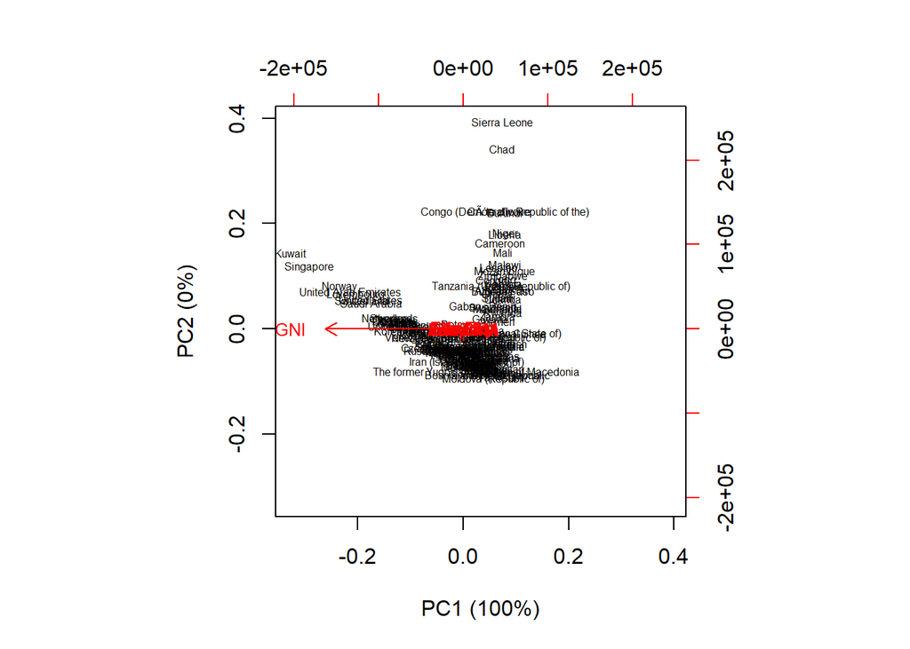

The second analysis is performed on the standardized dataset. This time there are 2 components, that capture 70 % of the variation, with first componen accounting 54 %.

Second component consists of female to male ratio in the labour force (0.72) and percentage of female representatives in parliament (0.64). This dimension describes the equality of men and women in relation to power.

```
## Standard deviations (1, .., p=8):
## [1] 2.0796591 1.1446342 0.8731711 0.7724212 0.6388233 0.5312363 0.4584886
## [8] 0.3244212
##
## Rotation (n x k) = (8 x 8):
##                   PC1         PC2         PC3         PC4         PC5
## Edu2.FM   -0.34780421  0.02201214 -0.33522080  0.69089531 -0.47573796
## Labo.FM    0.04099046  0.72355978 -0.58847217 -0.06167349  0.27067548
## Edu.Exp   -0.42776539  0.12287124 -0.08281142 -0.14787124  0.03857275
## Life.Exp  -0.44080871 -0.04340355  0.10505186 -0.08019736  0.12902296
## GNI       -0.36968433  0.12113853 -0.00901504 -0.60982622 -0.58939866
## Mat.Mor    0.43251606  0.17844542 -0.06052981 -0.23069612 -0.25999380
## Ado.Birth  0.40898841  0.09640031  0.02395493  0.10012510 -0.51630720
## Parli.F   -0.09512255  0.63496864  0.72049631  0.23543315 -0.02669666
##                   PC6         PC7         PC8
## Edu2.FM    0.19541963 -0.00974105 -0.15565360
## Labo.FM   -0.07188544  0.20185351  0.07416433
## Edu.Exp   -0.32798388 -0.81477700  0.01652132
## Life.Exp  -0.47103010  0.41201166 -0.61487106
## GNI        0.20439101  0.21782718  0.20018620
## Mat.Mor    0.23806413 -0.27496691 -0.72410250
## Ado.Birth -0.71883810  0.04747939  0.16516948
## Parli.F    0.10964692 -0.01534082  0.01588502
```

```
## Importance of components:
##                           PC1    PC2    PC3     PC4     PC5     PC6
## Standard deviation     2.0797 1.1446 0.8732 0.77242 0.63882 0.53124
## Proportion of Variance 0.5406 0.1638 0.0953 0.07458 0.05101 0.03528
## Cumulative Proportion  0.5406 0.7044 0.7997 0.87428 0.92529 0.96057
##                            PC7     PC8
## Standard deviation     0.45849 0.32442
## Proportion of Variance 0.02628 0.01316
## Cumulative Proportion  0.98684 1.00000
```

[figure not shown]

## Multiple correspondence analysis

Below is a summary of the variables in the tea data set from package FactoMineR. Since there are too many variables and I don’t have a theory about tea drinking at hand I’ll just randomly select half of the variables for the analysis.

```
## 'data.frame':    300 obs. of  36 variables:
##  $ breakfast       : Factor w/ 2 levels "breakfast","Not.breakfast": 1 1 2 2 1 2 1 2 1 1 ...
##  $ tea.time        : Factor w/ 2 levels "Not.tea time",..: 1 1 2 1 1 1 2 2 2 1 ...
##  $ evening         : Factor w/ 2 levels "evening","Not.evening": 2 2 1 2 1 2 2 1 2 1 ...
##  $ lunch           : Factor w/ 2 levels "lunch","Not.lunch": 2 2 2 2 2 2 2 2 2 2 ...
##  $ dinner          : Factor w/ 2 levels "dinner","Not.dinner": 2 2 1 1 2 1 2 2 2 2 ...
##  $ always          : Factor w/ 2 levels "always","Not.always": 2 2 2 2 1 2 2 2 2 2 ...
##  $ home            : Factor w/ 2 levels "home","Not.home": 1 1 1 1 1 1 1 1 1 1 ...
##  $ work            : Factor w/ 2 levels "Not.work","work": 1 1 2 1 1 1 1 1 1 1 ...
##  $ tearoom         : Factor w/ 2 levels "Not.tearoom",..: 1 1 1 1 1 1 1 1 1 2 ...
##  $ friends         : Factor w/ 2 levels "friends","Not.friends": 2 2 1 2 2 2 1 2 2 2 ...
##  $ resto           : Factor w/ 2 levels "Not.resto","resto": 1 1 2 1 1 1 1 1 1 1 ...
##  $ pub             : Factor w/ 2 levels "Not.pub","pub": 1 1 1 1 1 1 1 1 1 1 ...
##  $ Tea             : Factor w/ 3 levels "black","Earl Grey",..: 1 1 2 2 2 2 2 1 2 1 ...
##  $ How             : Factor w/ 4 levels "alone","lemon",..: 1 3 1 1 1 1 1 3 3 1 ...
```

[output cut: 22 more lines]

```
##          breakfast           tea.time          evening          lunch
##  breakfast    :144   Not.tea time:131   evening    :103   lunch    : 44
##  Not.breakfast:156   tea time    :169   Not.evening:197   Not.lunch:256
##
##
##
##
##
##         dinner           always          home           work
##  dinner    : 21   always    :103   home    :291   Not.work:213
##  Not.dinner:279   Not.always:197   Not.home:  9   work    : 87
##
##
##
##
##
##         tearoom           friends          resto          pub
##  Not.tearoom:242   friends    :196   Not.resto:221   Not.pub:237
##  tearoom    : 58   Not.friends:104   resto    : 79   pub    : 63
##
##
##
##
##
##         Tea         How           sugar                     how
##  black    : 74   alone:195   No.sugar:155   tea bag           :170
##  Earl Grey:193   lemon: 33   sugar   :145   tea bag+unpackaged: 94
##  green    : 33   milk : 63                  unpackaged        : 36
##                  other:  9
##
##
##
##                   where                 price          age        sex
##  chain store         :192   p_branded      : 95   Min.   :15.00   F:178
##  chain store+tea shop: 78   p_cheap        :  7   1st Qu.:23.00   M:122
##  tea shop            : 30   p_private label: 21   Median :32.00
##                             p_unknown      : 12   Mean   :37.05
##                             p_upscale      : 53   3rd Qu.:48.00
##                             p_variable     :112   Max.   :90.00
##
```

[output cut: 25 more lines]

```
##  feminine    :129   Not.sophisticated: 85   No.slimming:255
##  Not.feminine:171   sophisticated    :215   slimming   : 45
##
##
##
##
##
##         exciting          relaxing              effect.on.health
##  exciting   :116   No.relaxing:113   effect on health   : 66
##  No.exciting:184   relaxing   :187   No.effect on health:234
##
##
##
##
##
```

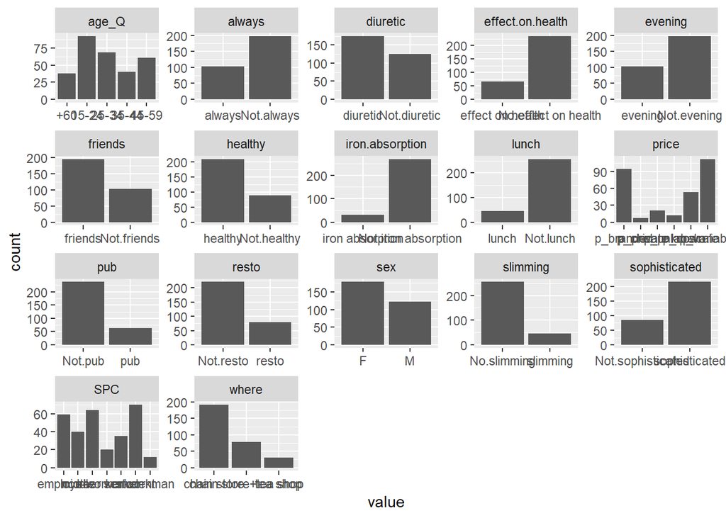

Task is to fit a multiple correspondence analysis to the data. Results are below. Selecting the columns at random doesn’t make much sense.

```r
mca <- MCA(tea1, graph = FALSE)
summary(mca)
```

```
##
## Call:
## MCA(X = tea1, graph = FALSE)
##
##
## Eigenvalues
##                        Dim.1   Dim.2   Dim.3   Dim.4   Dim.5   Dim.6
## Variance               0.134   0.115   0.113   0.093   0.088   0.081
## % of var.              7.575   6.539   6.393   5.250   4.991   4.612
## Cumulative % of var.   7.575  14.115  20.508  25.758  30.748  35.360
##                        Dim.7   Dim.8   Dim.9  Dim.10  Dim.11  Dim.12
## Variance               0.078   0.077   0.072   0.068   0.065   0.062
## % of var.              4.413   4.361   4.105   3.861   3.671   3.526
## Cumulative % of var.  39.773  44.134  48.239  52.100  55.771  59.297
##                       Dim.13  Dim.14  Dim.15  Dim.16  Dim.17  Dim.18
## Variance               0.061   0.057   0.057   0.054   0.051   0.048
## % of var.              3.437   3.249   3.205   3.081   2.897   2.712
## Cumulative % of var.  62.734  65.982  69.187  72.268  75.165  77.877
##                       Dim.19  Dim.20  Dim.21  Dim.22  Dim.23  Dim.24
## Variance               0.046   0.043   0.043   0.040   0.038   0.038
## % of var.              2.603   2.447   2.425   2.284   2.170   2.133
## Cumulative % of var.  80.480  82.927  85.352  87.636  89.806  91.939
##                       Dim.25  Dim.26  Dim.27  Dim.28  Dim.29  Dim.30
## Variance               0.032   0.030   0.028   0.020   0.018   0.015
## % of var.              1.806   1.684   1.565   1.136   1.002   0.868
## Cumulative % of var.  93.745  95.429  96.994  98.130  99.132 100.000
##
## Individuals (the 10 first)
##                        Dim.1    ctr   cos2    Dim.2    ctr   cos2    Dim.3
## 1                   |  0.277  0.192  0.027 | -0.662  1.266  0.156 | -0.063
## 2                   |  0.216  0.116  0.037 | -0.181  0.095  0.026 | -0.282
## 3                   | -0.142  0.050  0.011 | -0.070  0.014  0.003 |  0.243
## 4                   | -0.216  0.116  0.050 | -0.233  0.157  0.059 | -0.248
## 5                   | -0.029  0.002  0.001 | -0.402  0.467  0.113 | -0.055
## 6                   | -0.306  0.234  0.054 | -0.377  0.411  0.082 | -0.499
## 7                   |  0.159  0.063  0.017 | -0.294  0.249  0.059 |  0.222
## 8                   |  0.140  0.049  0.014 | -0.296  0.254  0.063 | -0.002
## 9                   |  0.578  0.834  0.181 | -0.323  0.301  0.056 |  0.373
## 10                  |  0.447  0.497  0.105 | -0.174  0.087  0.016 |  0.368
##                        ctr   cos2
```

[output cut: 32 more lines]

```
## employee            -3.797 | -0.458  2.146  0.051 -3.914 |
## middle              -4.119 |  0.265  0.487  0.011  1.796 |
##
## Categorical variables (eta2)
##                       Dim.1 Dim.2 Dim.3
## slimming            | 0.013 0.087 0.065 |
## effect.on.health    | 0.033 0.006 0.003 |
## friends             | 0.108 0.057 0.160 |
## diuretic            | 0.009 0.089 0.019 |
## SPC                 | 0.586 0.511 0.211 |
## where               | 0.228 0.175 0.309 |
## age_Q               | 0.598 0.501 0.151 |
## lunch               | 0.051 0.103 0.065 |
## sex                 | 0.084 0.140 0.042 |
## pub                 | 0.105 0.069 0.054 |
```

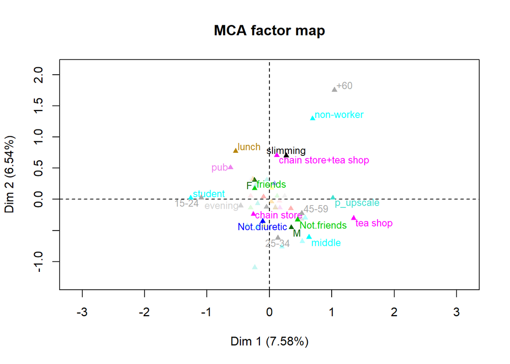

```r
plot(mca, invisible=c("ind"), habillage="quali", cex=0.8, selectMod="contrib 20", xlim=c(-2,2))
```